# 4 – sampling

## The normal distribution

To plot a function in R, you first need to generate a list of x and y coordinates.

### Plotting the standard normal distribution

Here is how to plot the standard normal distribution $Z \sim Nor(\mu = 0, \sigma = 1)$:

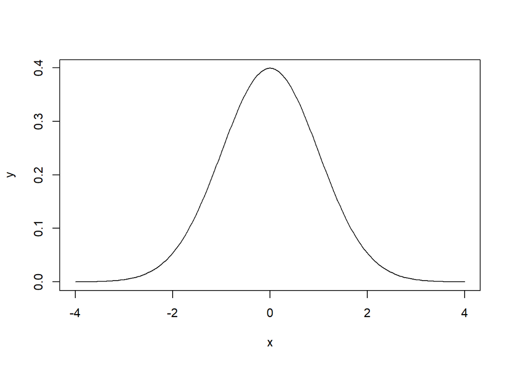

```r
# Make a list of 200 numbers evenly distributed over the interval [-4, 4]
x <- seq(from = -4,
         to = 4,
         length.out = 200)
# Calculate for every x value the corresponding value on the Gauss curve
y <- dnorm(x)

# Plot the values, with type "lines" (connect the data points with lines)
plot(x, y, type = 'l')
```

### Plotting a normal distribution

We will plot $X \sim Nor(\mu = 170, \sigma = 5)$. All “interesting” point on the Gauss curve are located 4 times the standard deviation to the left and to the right of the mean.

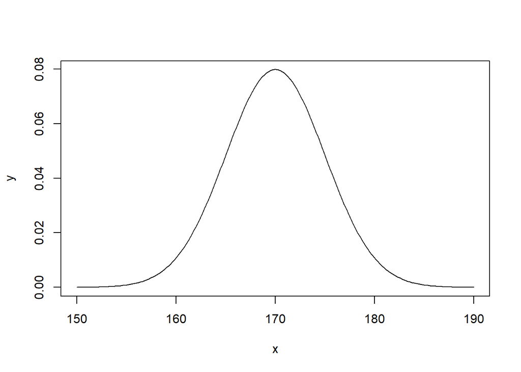

```r
m <- 170 # mean
s <- 5  # standard deviation
# Select the "interesting" range of x values
x <- seq(from = m-4*s,
         to = m+4*s,
         length.out = 200)
# Calculate the probability density function
y <- dnorm(x, m, s)

# Plot the graph
plot(x, y, type = 'l')
```

The *shape* of the curve is exactly the same as for the *standard* normal distribution. Only the scale (on both the x and the y axis) is different.

### Combining a histogram with the density function

Here is how to combine a histogram with the “theoritical” density function:

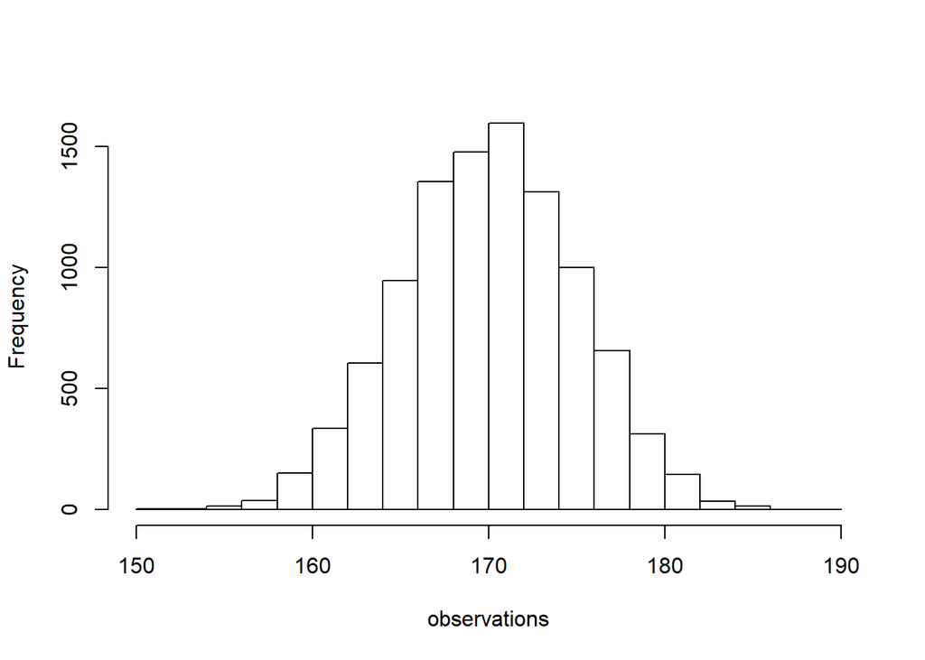

```r
# Generate 10000 normal distributed random samples:
m <- 170
s <- 5
n <- 10000
observations <- rnorm(n, m, s)

# Draw a histogram (with an empty title)
histogram <- hist(observations, main="")
```

The histogram above contains *absolute* frequencies. We can also draw a histogram with *densities*. In this case the area of a bar is the *relative* frequency of that bar. (The *density* is the *relative* frequency divided by the *width* of the bar.) The sum of all the areas of all the bars is one. This corresponds with the area under the Gauss curve which is also equal to one.

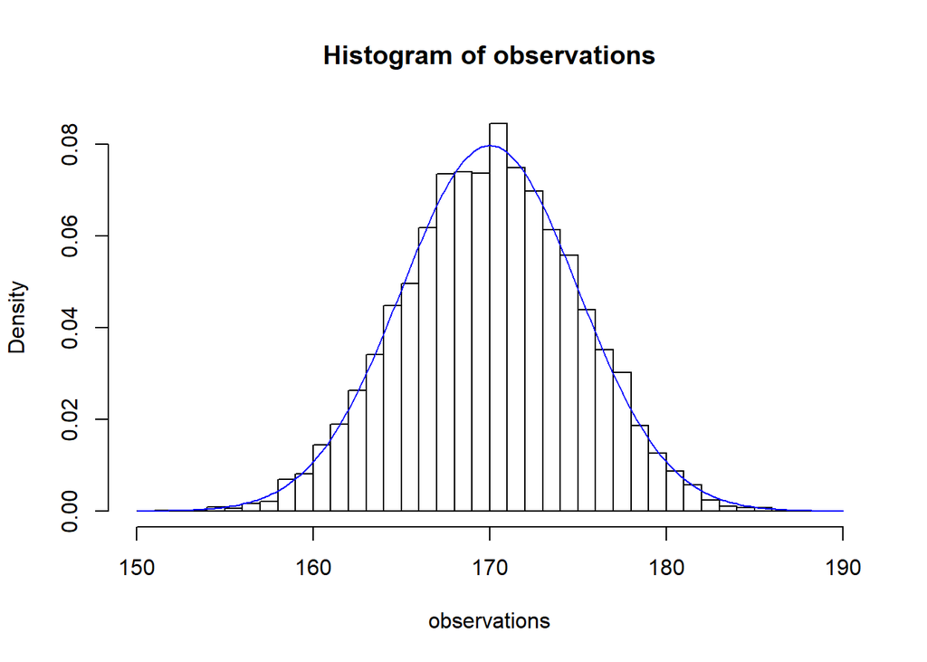

```r
# Draw a histogram with densities (instead of absolute frequencies)
# The option "breaks" tunes the number of bars in the histogram
hist(observations, freq = FALSE, breaks = 50)

# Calculate the probability density function
y <- dnorm(x, m, s)

# Add the function to the histogram
lines(x, y, col = 'blue')
```

The function `lines` *adds* the plot on top of the existing histogram. With the `plot` function, the histogram would be removed/overwritten.

## Probabilities based on the normal distribution

Suppose, Superman has a response time which has a normal distribution with an average of 5 milliseconds and a standard deviation of 1.5 ms.

```r
m <- 5
s <- 1.5
```

What’s the probability that his response time will be longer than 6 ms? Mathematical notation: $P(X > 6)$

```r
# First calculate the z-score
x <- 6
z <- (x - m) / s
z
```

```
## [1] 0.6666667
```

```r
1-pnorm(z)
```

```
## [1] 0.2524925
```

```r
1-pnorm(x, m, s)
```

```
## [1] 0.2524925
```

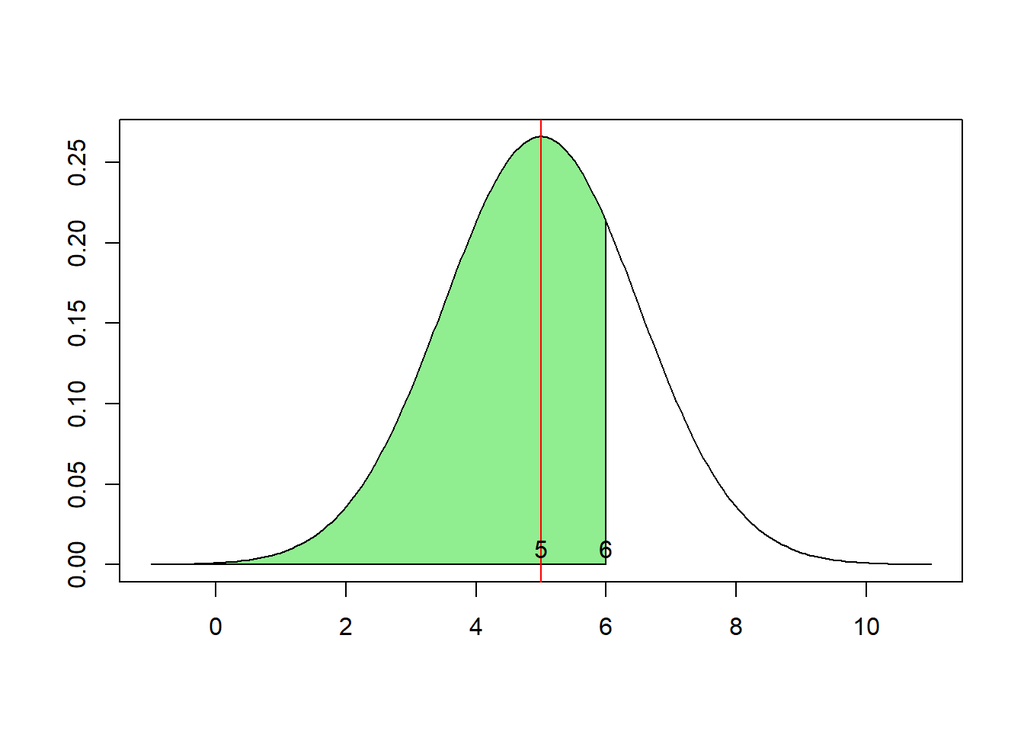

```r
# x-values
x_interval <- seq(m - 4 * s, m + 4 * s, length=200)
# y-values
norm_dist <- dnorm(x_interval, m, s)
plot(x_interval, norm_dist,
     type = 'l', xlab = '', ylab = '')

# colour the area to the left of x
i <- x_interval <= x
polygon(
  c(x_interval[i], x,              x),
  c(norm_dist[i],  dnorm(x, m, s), 0),
  col = 'lightgreen')
text(x, .01, x)

# show the average using a red vertical line
abline(v = m, col='red')
text(m, .01, m)
```

Other examples:

1. Probability for the response time to be *less* than 4 ms?

   ```r
   pnorm(4, m, s)
   ```

   ```
   ## [1] 0.2524925
   ```

2. Probability for the response time to be *more* than 7 ms?

   ```r
   1 - pnorm(7, m, s)
   ```

   ```
   ## [1] 0.09121122
   ```

3. Probability for the response time to be *between* 2 and 6,5 ms?

   ```r
   pnorm(6.5, m, s) - pnorm(2, m, s)
   ```

   ```
   ## [1] 0.8185946
   ```

4. Below which level are 80% of his response times?

   ```r
   qnorm(.8, m, s)
   ```

   ```
   ## [1] 6.262432
   ```

## Confidence interval (large samples)

Suppose we have made 100 measurements of Superman’s reaction time and we obtain a sample average of 5.2 ms. We assume that we know the *actual* standard deviation of its reaction time and that it is 1.5 ms.

To determine a confidence interval, proceed as follows:

1. As an initial estimate (point estimate), we take the sample average ($\overline{x}$) and choose a confidence level, e.g. $1 - \alpha = 0.95$ (or 95%).
2. We then look for the $z$ score between which 95% of all values lie at a standard normal distribution.
3. We use this to determine the values to the left and right of the sample average between which we expect 95% of the values to end up for the probability distribution that we take out of the *central limit theorem*.

```r
# Step 1
m <- 5.2      # mean of the sample
s <- 1.5      # standard deviation of the population
n <- 100      # size of the sample
alpha <- 0.05 # 1 - alpha is the confidence level

# Step 2
z <- qnorm(1-alpha/2) # divide by 2! (see slides)
z
```

```
## [1] 1.959964
```

```r
# Step 3: confidence interval
low  <- m - z * s / sqrt(n)
high <- m + z * s / sqrt(n)
c(low, high)
```

```
## [1] 4.906005 5.493995
```

So, we can say with a confidence level of 95% that the response time of Superman is between 4.91 en 5.49 ms.

## Confidence interval for small samples

If we have a small sample (less than 30), the assumption we made in the central limit setting is dropped. In that case, we cannot use the normal distribution anymore.

Through the so-called Student-$t$distribution, however, there is still a way to construct a confidence interval. This distribution *resembles* the normal distribution, but it also takes into account the sample size $n$. Therefore the density function gets an additional parameter called the degrees of *freedom* (abbreviated to `df`). It is equal to $n - 1$.

The smaller the degrees of freedom, the “flatter” the curve and the wider the obtained confidence intervals. This models the greater uncertainty we get because of the small sample. The larger $n$, the better the curve will resemble the normal distribution.

In the graph below you will find the density function for the Student-$t$ distribution for different degrees of freedom:

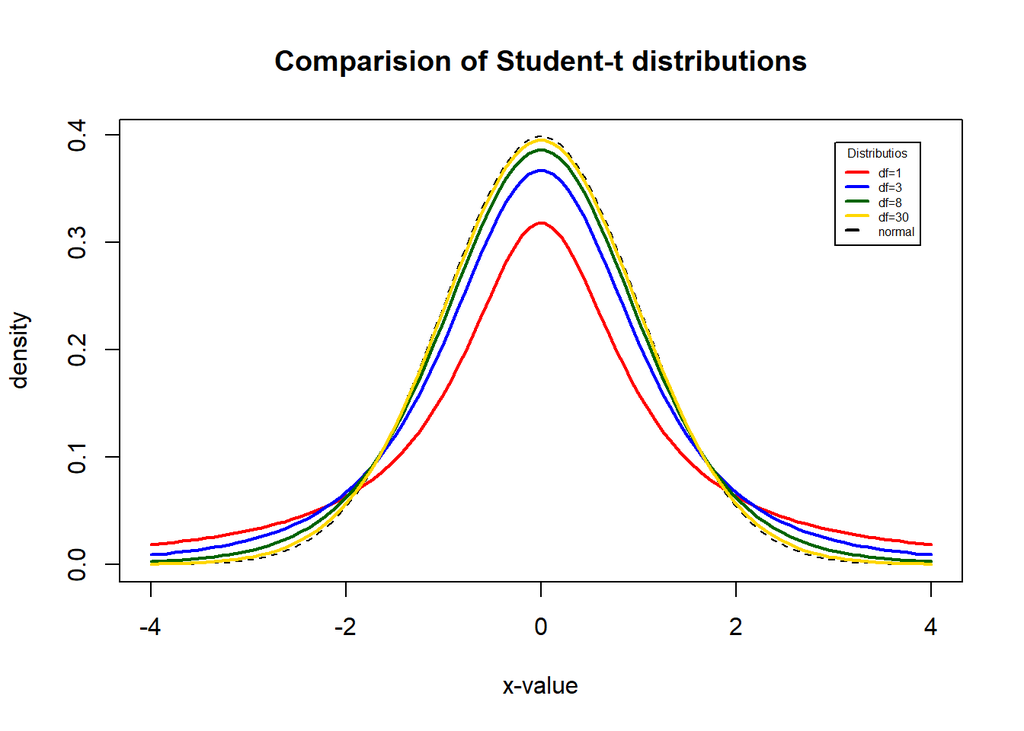

```r
# Bron: https://www.statmethods.net/advgraphs/probability.html
x <- seq(-4, 4, length=100) # x-values
std_norm_dist <- dnorm(x)   # standard normal distrib (to compare)
degf <- c(1, 3, 8, 30)      # 4 different degrees of freedom

# colors/labels
colors <- c("red", "blue", "darkgreen", "gold", "black")
labels <- c("df=1", "df=3", "df=8", "df=30", "normal")

# plot standard normal distrib
plot(x, std_norm_dist,
     type="l", lty=2,
     xlab="x-value", ylab="density",
     main="Comparision of Student-t distributions")

# plot the Student-t distributions
for (i in 1:4){
  lines(x, dt(x,degf[i]), lwd=2, col=colors[i])
}

legend("topright", inset=.05, title="Distributios",
       labels, lwd=2, lty=c(1, 1, 1, 1, 2), col=colors,
       cex = .5)
```

To illustrate this, we take the same example as above, but assume that the sample size was only 15.

```r
# Step 1
m <- 5.2      # sample mean
s <- 1.5      # standard deviation of the population
n <- 15       # size of the sample
alpha <- 0.05 # 1 - alpha is the confidence level

# Step 2, now with Student-t distribution!
t <- qt(1-alpha/2, df = n - 1)
t
```

```
## [1] 2.144787
```

```r
# Step 3: confidence interval
low  <- m - t * s / sqrt(n)
high <- m + t * s / sqrt(n)
c(low, high)
```

```
## [1] 4.369328 6.030672
```

Now, we can state with a confidence level of 95% that the response time of Superman is between 4.37 en 6.03 ms.

This interval is much wider than what we obtained with a larger sample. We are therefore less certain about the position of the population average.

## Confidence interval for fractions

Some variables have only two possible values, e.g. yes/no, true/false, success/failure, 1/0, etc. Using a sample, we want to estimate the actual ratio between these two results over the entire population.

Suppose we want to know what percentage of superheroes can fly (on their own). 100 superheroes were interviewed, 6 of whom were able to demonstrate that they can indeed fly. Construct a 95% confidence interval for the expected percentage of flying superheroes in the entire pupulation.

```r
# Step 1.
n <- 100   # sample size
k <- 6     # number of "successes" in the sample
a <- 0.05  # confidence level 95%

p <- k / n # estimate for the percentage of successes
q <- 1 - p # estimate for the percentage of failures
c(p, q)
```

```
## [1] 0.06 0.94
```

```r
# Step 2 (we use the normal distribution again)
z <- qnorm(1-a/2)

# Step 3.
low <- p - z * sqrt(p*q/n)
high <- p + z * sqrt(p*q/n)
c(low, high)
```

```
## [1] 0.01345343 0.10654657
```

We can state with a confidence level of 95% that between 1.3% and 10.6% of the super hero’s can fly.

(This document was translated with the help of www.DeepL.com/Translator)